# Métodos Numéricos Aplicados a Finanças — Turma 2025

```r
# ambas as séries são I(1)
dynlm(aus~0+usa, gdp) -> m
dynlm(aus~-1+usa, gdp) -> m
dynlm(aus~usa-1, gdp) -> m
m %>% summary
```

```
##
## Time series regression with "numeric" data:
## Start = 1, End = 124
##
## Call:
## dynlm(formula = aus ~ usa - 1, data = gdp)
##
## Residuals:
##      Min       1Q   Median       3Q      Max
## -2.72821 -1.06932 -0.08543  0.91592  2.26603
##
## Coefficients:
##     Estimate Std. Error t value Pr(>|t|)
## usa 0.985350   0.001657   594.8   <2e-16 ***
## ---
## Signif. codes:  0 '***' 0.001 '**' 0.01 '*' 0.05 '.' 0.1 ' ' 1
##
## Residual standard error: 1.219 on 123 degrees of freedom
## Multiple R-squared:  0.9997, Adjusted R-squared:  0.9996
## F-statistic: 3.538e+05 on 1 and 123 DF,  p-value: < 2.2e-16
```

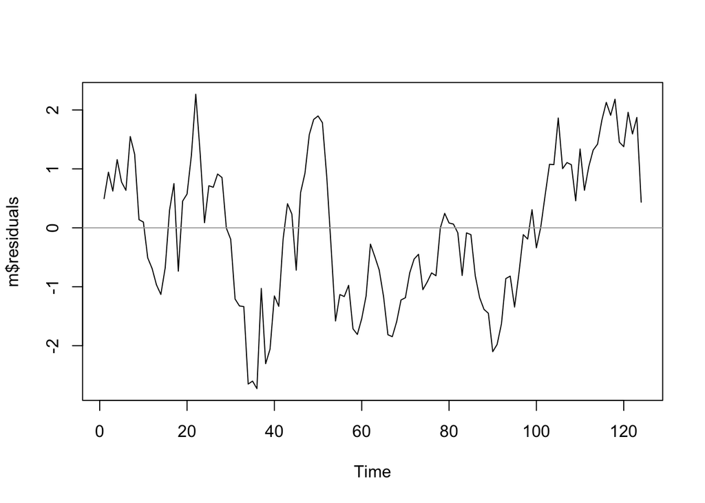

```r
plot.ts(m$residuals); abline(h = 0, col = "darkgray")
```

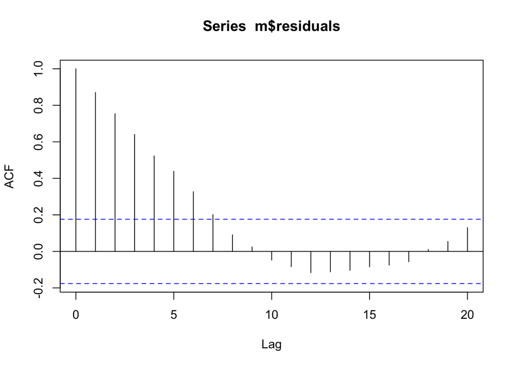

```r
acf(m$residuals)
```

```r
# como o decaimento é rápido, uso os lags significativos (7)
# lembrando que H0: a série em teste é não-estacionária
# no caso, estamos testando o erro (resíduos) da regressão
# o p-valor rejeita H0 (0.03 < 0.05), logo a série é estacionária (por pouco)
m$residuals %>% adf.test(k = 7)
```

```
##
##  Augmented Dickey-Fuller Test
##
## data:  .
## Dickey-Fuller = -3.6606, Lag order = 7, p-value = 0.03071
## alternative hypothesis: stationary
```

Colonescu faz a regressão de Dickey-Fuller manualmente, sem tendência e sem constante, com apenas um lag

```r
m$residuals -> ehat
ehat = ts(ehat)
dynlm(d(ehat)~L(ehat)-1) %>% summary
```

```
##
## Time series regression with "ts" data:
## Start = 2, End = 124
##
## Call:
## dynlm(formula = d(ehat) ~ L(ehat) - 1)
##
## Residuals:
##      Min       1Q   Median       3Q      Max
## -1.48488 -0.33704 -0.00385  0.46559  1.35065
##
## Coefficients:
##         Estimate Std. Error t value Pr(>|t|)
## L(ehat) -0.12794    0.04428  -2.889  0.00457 **
## ---
## Signif. codes:  0 '***' 0.001 '**' 0.01 '*' 0.05 '.' 0.1 ' ' 1
##
## Residual standard error: 0.5985 on 122 degrees of freedom
## Multiple R-squared:  0.06405,    Adjusted R-squared:  0.05637
## F-statistic: 8.348 on 1 and 122 DF,  p-value: 0.00457
```

$$\Delta \text{aus}\,_t = \alpha_{10}+\alpha_{11}\ \widehat{ e }_{t-1} + \ ^y\nu_t\\
\Delta \text{usa}\,_t = \alpha_{20}+\alpha_{21}\ \widehat{ e }_{t-1} + \ ^x\nu_t\\$$

d(aus)~L(ehat)

Quero saber se $\alpha_{11}$ é significativo.

d(usa)~L(ehat)

Quero saber se $\alpha_{21}$ é significativo.

```r
gdp = ts(gdp)
vecaus<- dynlm(d(aus)~L(ehat), data=gdp)
# O erro no tempo t-1 (L(ehat)) tem uma influência significativa e negativa
# sobre a taxa de variação do gdp da aus
# d(aus) = aus[t]-aus[t-1]
summary(vecaus)
```

```
##
## Time series regression with "ts" data:
## Start = 2, End = 124
##
## Call:
## dynlm(formula = d(aus) ~ L(ehat), data = gdp)
##
## Residuals:
##      Min       1Q   Median       3Q      Max
## -1.82072 -0.41633  0.01881  0.41823  1.73368
##
## Coefficients:
##             Estimate Std. Error t value Pr(>|t|)
## (Intercept)  0.49171    0.05791   8.491 6.12e-14 ***
## L(ehat)     -0.09870    0.04752  -2.077   0.0399 *
## ---
## Signif. codes:  0 '***' 0.001 '**' 0.01 '*' 0.05 '.' 0.1 ' ' 1
##
## Residual standard error: 0.6409 on 121 degrees of freedom
## Multiple R-squared:  0.03443,    Adjusted R-squared:  0.02645
## F-statistic: 4.315 on 1 and 121 DF,  p-value: 0.03989
```

```r
vecusa <- dynlm(d(usa)~L(ehat), data=gdp)
# O erro no tempo t-1 (L(ehat)) não tem uma influência significativa
# sobre a taxa de variação do gdp do usa
# d(usa) = usa[t]-usa[t-1]
summary(vecusa)
```

```
##
## Time series regression with "ts" data:
## Start = 2, End = 124
##
## Call:
## dynlm(formula = d(usa) ~ L(ehat), data = gdp)
##
## Residuals:
##      Min       1Q   Median       3Q      Max
## -1.54329 -0.30388  0.03483  0.36117  1.47005
##
## Coefficients:
##             Estimate Std. Error t value Pr(>|t|)
## (Intercept)  0.50988    0.04668   10.92   <2e-16 ***
## L(ehat)      0.03025    0.03830    0.79    0.431
## ---
## Signif. codes:  0 '***' 0.001 '**' 0.01 '*' 0.05 '.' 0.1 ' ' 1
##
## Residual standard error: 0.5166 on 121 degrees of freedom
## Multiple R-squared:  0.005129,   Adjusted R-squared:  -0.003093
## F-statistic: 0.6238 on 1 and 121 DF,  p-value: 0.4312
```

## 2.2 Usando o teste de Johanssen

Teste genérico que pode ser aplicado a mais de 2 séries simultaneamente.

```r
library(urca)
# Este teste de Dickey-Fuller com TODAS as opções
# mais sofisticado e um tanto mais difícil de interpretar
# urca::ur.df(gdp[,"usa"]) %>% summary
#
# Teste ca(Cointegration Ananlysis).jo(Johanssen)
# duas versões: eigen (mais rigoroso) e trace (mais leniente)
# Values of teststatistic and critical values of test:
# ler de baixo para cima enquanto o valor da estatística de teste
# for maior que os valores de referência
# Como o valor da estatística de teste é menor que os valores de referência
# para a linha r = 0, significa que não há relações de cointegração
urca::ca.jo(gdp[,1:2], type = "eigen", K = 2) -> jo
jo %>% summary
```

```
##
## ######################
## # Johansen-Procedure #
## ######################
##
## Test type: maximal eigenvalue statistic (lambda max) , with linear trend
##
## Eigenvalues (lambda):
## [1] 0.09533308 0.04381035
##
## Values of teststatistic and critical values of test:
##
##           test 10pct  5pct  1pct
## r <= 1 |  5.47  6.50  8.18 11.65
## r = 0  | 12.22 12.91 14.90 19.19
##
## Eigenvectors, normalised to first column:
## (These are the cointegration relations)
##
##            usa.l2    aus.l2
## usa.l2  1.0000000  1.000000
## aus.l2 -0.9381727 -1.087827
##
## Weights W:
## (This is the loading matrix)
##
##           usa.l2       aus.l2
## usa.d 0.03725646 -0.050284307
## aus.d 0.13645769 -0.003954803
```

```r
# Values of teststatistic and critical values of test:
# ler de baixo para cima enquanto o valor da estatística de teste
# for maior que os valores de referência
# Como o valor da estatística de teste é maior que o valor de referência
# de 10%
# para a linha r = 0, significa que há r = 1 relações de cointegração
urca::ca.jo(gdp[,1:2], type = "trace", K = 2) -> jo
jo %>% summary
```

```
##
## ######################
## # Johansen-Procedure #
## ######################
##
## Test type: trace statistic , with linear trend
##
## Eigenvalues (lambda):
## [1] 0.09533308 0.04381035
##
## Values of teststatistic and critical values of test:
##
##           test 10pct  5pct  1pct
## r <= 1 |  5.47  6.50  8.18 11.65
## r = 0  | 17.69 15.66 17.95 23.52
##
## Eigenvectors, normalised to first column:
## (These are the cointegration relations)
##
##            usa.l2    aus.l2
## usa.l2  1.0000000  1.000000
## aus.l2 -0.9381727 -1.087827
##
## Weights W:
## (This is the loading matrix)
##
##           usa.l2       aus.l2
## usa.d 0.03725646 -0.050284307
## aus.d 0.13645769 -0.003954803
```

```r
# r = 1 é o número de relações de cointegração que foram identificadas
# no teste de Johanssen. Como são duas variáveis, o máximo possível
# é uma relação.
urca::cajorls(jo, r = 1) -> vecm
vecm$beta
```

```
##              ect1
## usa.l2  1.0000000
## aus.l2 -0.9381727
```

```r
vecm$rlm %>% summary
```

```
## Response usa.d :
##
## Call:
## lm(formula = usa.d ~ ect1 + constant + usa.dl1 + aus.dl1 - 1,
##     data = data.mat)
##
## Residuals:
##      Min       1Q   Median       3Q      Max
## -1.48817 -0.27760 -0.00453  0.36786  1.52868
##
## Coefficients:
##          Estimate Std. Error t value Pr(>|t|)
## ect1      0.03726    0.03175   1.173  0.24303
## constant  0.18021    0.15211   1.185  0.23848
## usa.dl1   0.26537    0.09765   2.718  0.00757 **
## aus.dl1   0.02954    0.08411   0.351  0.72606
## ---
## Signif. codes:  0 '***' 0.001 '**' 0.01 '*' 0.05 '.' 0.1 ' ' 1
##
## Residual standard error: 0.4934 on 118 degrees of freedom
## Multiple R-squared:  0.552,  Adjusted R-squared:  0.5368
## F-statistic: 36.35 on 4 and 118 DF,  p-value: < 2.2e-16
##
##
## Response aus.d :
##
## Call:
## lm(formula = aus.d ~ ect1 + constant + usa.dl1 + aus.dl1 - 1,
##     data = data.mat)
##
## Residuals:
##     Min      1Q  Median      3Q     Max
## -1.6457 -0.4018 -0.0193  0.4121  1.4758
##
## Coefficients:
##          Estimate Std. Error t value Pr(>|t|)
## ect1      0.13646    0.03877   3.520 0.000615 ***
## constant -0.27129    0.18571  -1.461 0.146730
## usa.dl1   0.34290    0.11923   2.876 0.004780 **
## aus.dl1  -0.13021    0.10269  -1.268 0.207297
## ---
## Signif. codes:  0 '***' 0.001 '**' 0.01 '*' 0.05 '.' 0.1 ' ' 1
##
## Residual standard error: 0.6024 on 118 degrees of freedom
## Multiple R-squared:  0.4771, Adjusted R-squared:  0.4594
## F-statistic: 26.92 on 4 and 118 DF,  p-value: 7.105e-16
```

Este é o mecanismo de correção de erros:

$$ect1 = 1.0000000\ usa.l2 - 0.9381727\ aus.l2$$

As equações de regressão indicam que $\Delta usa_t$ é afetado apenas por $\Delta usa_{t-1}$, ou seja, é um fenômeno puramente autoregressivo.

Por outro lado, $\Delta aus_t$ é afetado por $ect1_t$ e por $\Delta usa_{t-1}$

## 2.3 13.3 Estimating a VAR Model

E quando as séries não são cointegradas?

Faz-se um estudo de relações de curto prazo, que é um modelo VAR.

$$\Delta y_t = \beta_{10} + \beta_{11}\ \Delta y_{t-1} + \beta_{12}\ \Delta x_{t-1} +\ ^{\Delta y}\nu_t\\
\Delta x_t = \beta_{20} + \beta_{21}\ \Delta y_{t-1} + \beta_{22}\ \Delta x_{t-1} +\ ^{\Delta x}\nu_t\\[1em]$$

Faremos as primeiras diferenças (séries I(1)).

O modelo VAR é calculado nas séries estacionadas (primeira diferença).

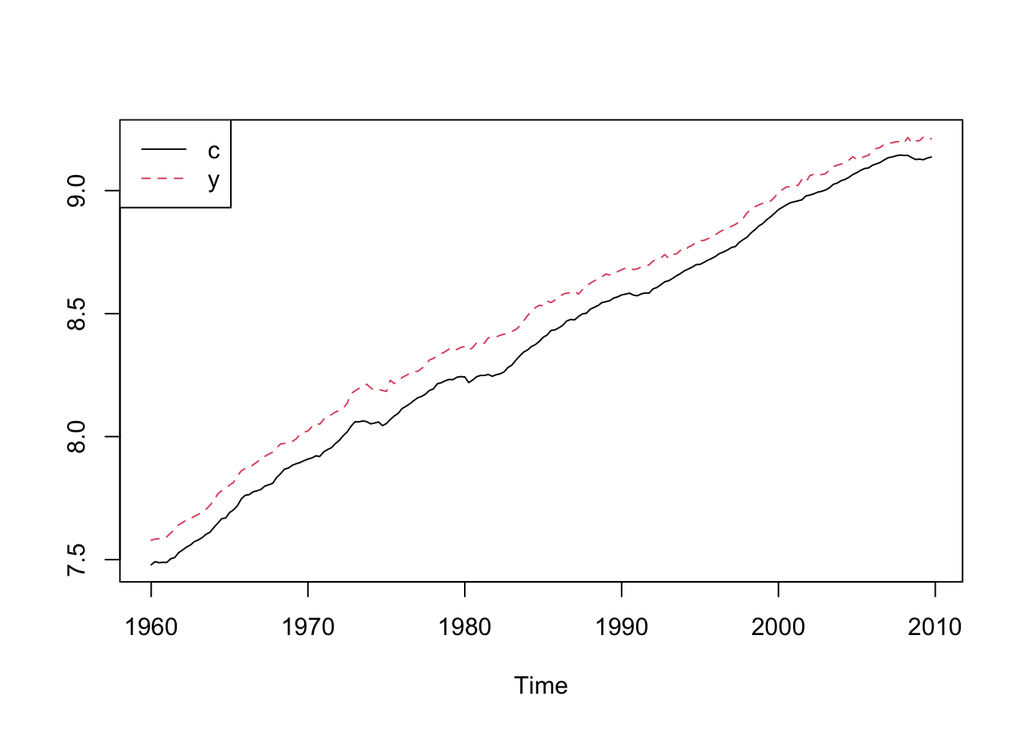

```r
data("fred", package="PoEdata")
# c = log do consumo
# y = log do excedente de renda
fred <- ts(fred, start=c(1960,1),end=c(2009,4),frequency=4)
ts.plot(fred[,"c"],fred[,"y"], type="l",
        lty=c(1,2), col=c(1,2))
legend("topleft", border=NULL, legend=c("c","y"),
       lty=c(1,2), col=c(1,2))
```

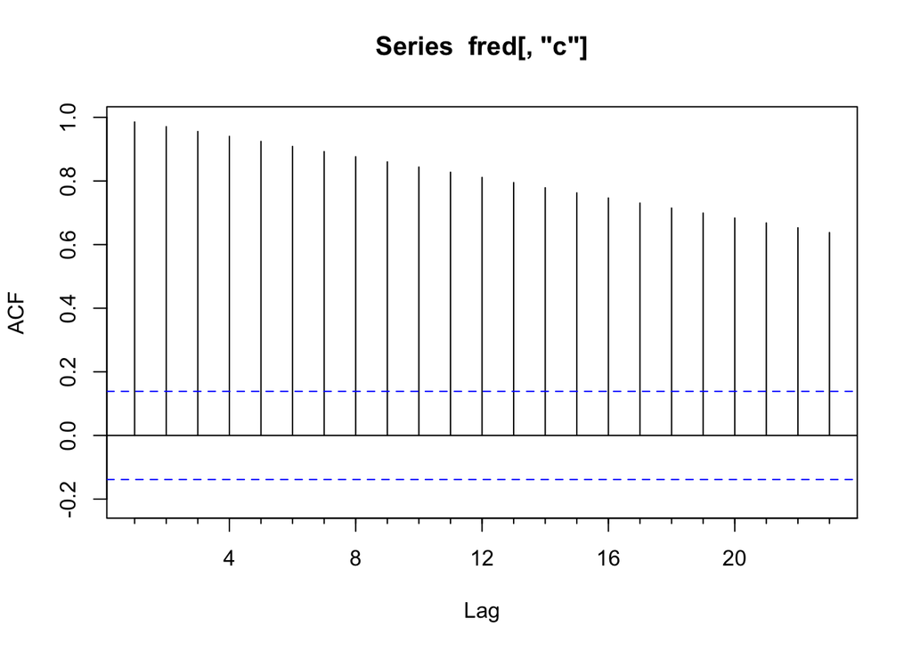

```r
Acf(fred[,"c"])
```

```r
adf.test(fred[,"c"])
```

```
##
##  Augmented Dickey-Fuller Test
##
## data:  fred[, "c"]
## Dickey-Fuller = -2.6202, Lag order = 5, p-value = 0.3163
## alternative hypothesis: stationary
```

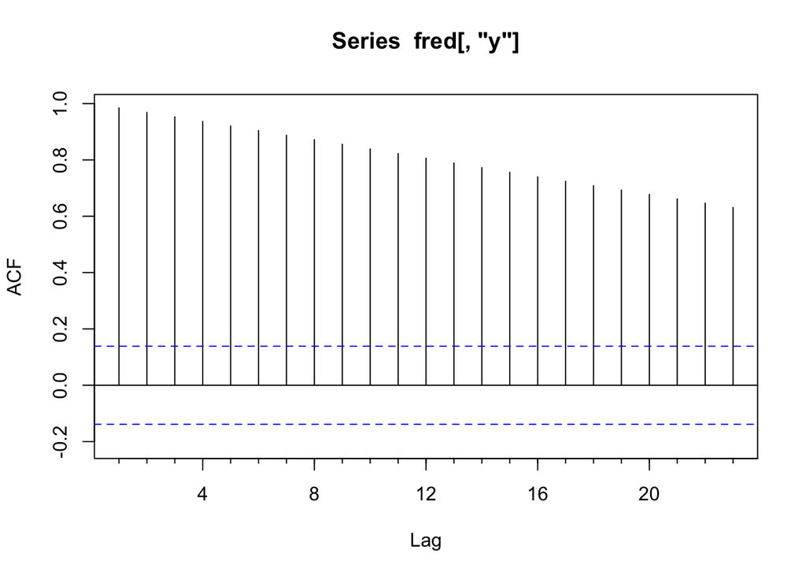

```r
Acf(fred[,"y"])
```

```r
adf.test(fred[,"y"])
```

```
##
##  Augmented Dickey-Fuller Test
##
## data:  fred[, "y"]
## Dickey-Fuller = -2.2905, Lag order = 5, p-value = 0.4544
## alternative hypothesis: stationary
```

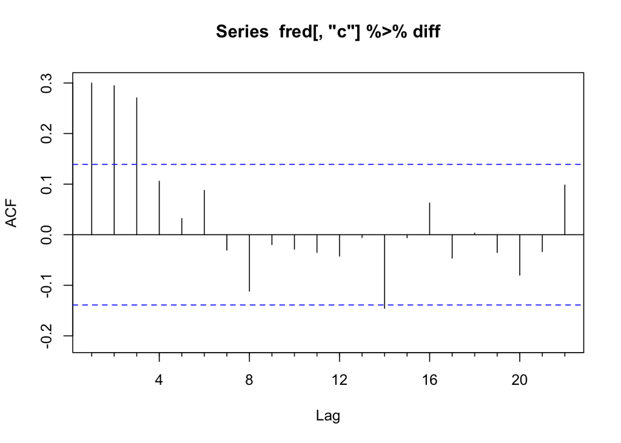

```r
Acf(fred[,"c"] %>% diff)
```

```r
adf.test(fred[,"c"] %>% diff, k = 3)
```

```
##
##  Augmented Dickey-Fuller Test
##
## data:  fred[, "c"] %>% diff
## Dickey-Fuller = -5.444, Lag order = 3, p-value = 0.01
## alternative hypothesis: stationary
```

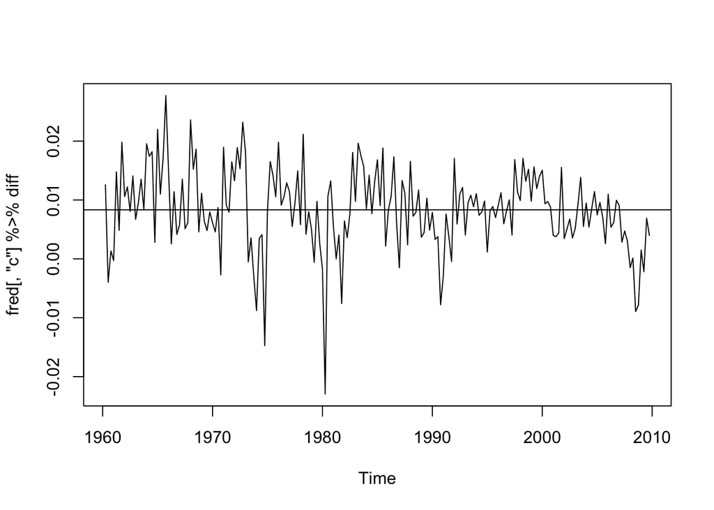

```r
ts.plot(fred[,"c"] %>% diff); abline(h = mean(fred[,"c"] %>% diff))
```

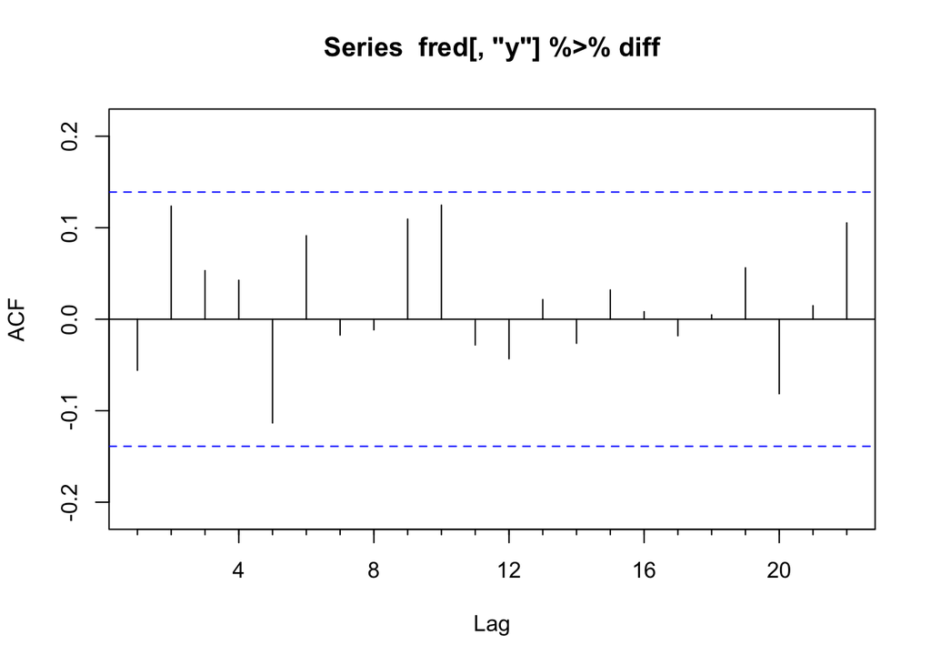

```r
Acf(fred[,"y"] %>% diff)
```

```r
adf.test(fred[,"y"] %>% diff, k = 3)
```

```
##
##  Augmented Dickey-Fuller Test
##
## data:  fred[, "y"] %>% diff
## Dickey-Fuller = -6.6213, Lag order = 3, p-value = 0.01
## alternative hypothesis: stationary
```

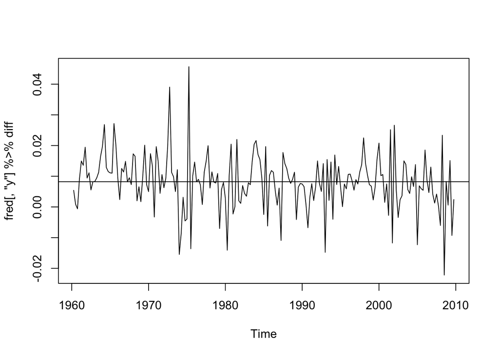

```r
ts.plot(fred[,"y"] %>% diff); abline(h = mean(fred[,"y"] %>% diff))
```

Ou seja, as séries são I(1)!

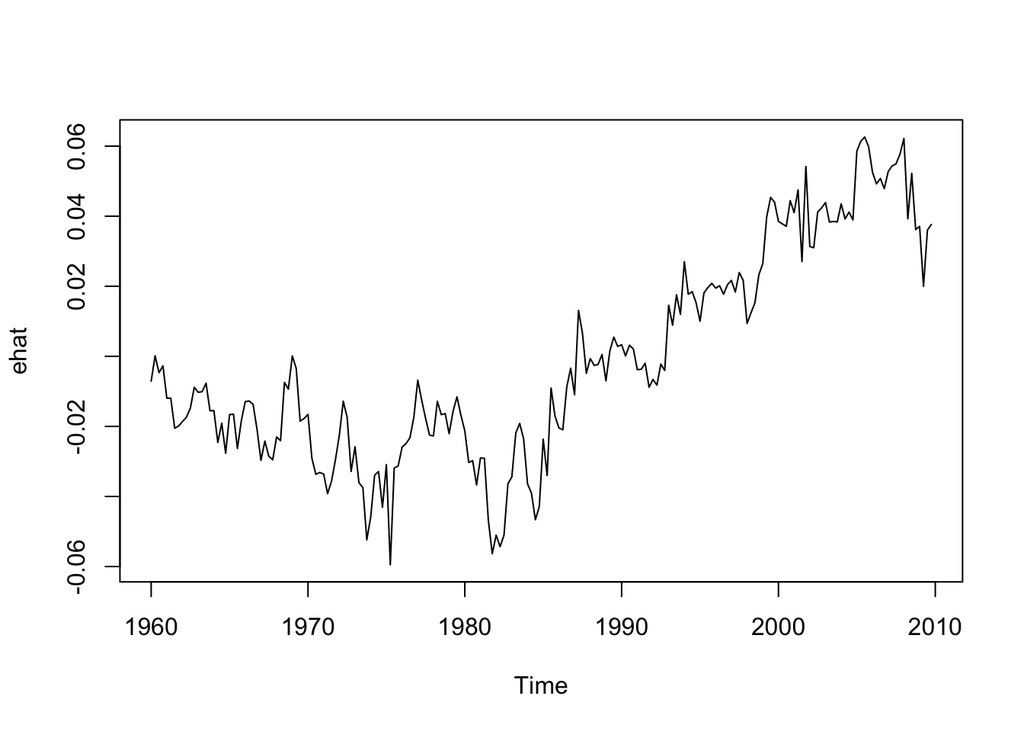

```r
cointcy <- dynlm(c~y-1, data=fred)
ehat <- resid(cointcy)
plot.ts(ehat)
```

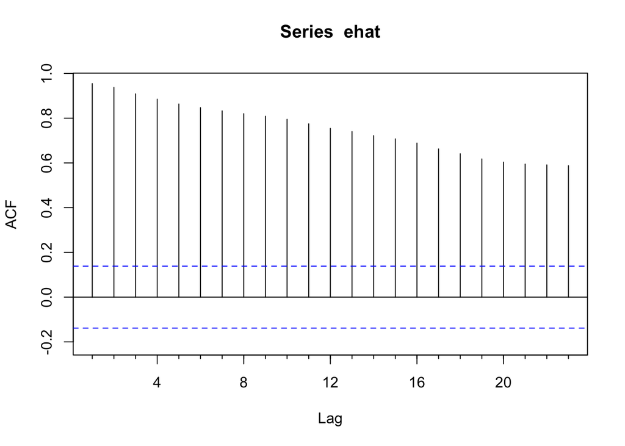

```r
Acf(ehat)
```

```r
adf.test(ehat)
```

```
##
##  Augmented Dickey-Fuller Test
##
## data:  ehat
## Dickey-Fuller = -2.5784, Lag order = 5, p-value = 0.3338
## alternative hypothesis: stationary
```

O termo de erro é não-estacionário, o que viola a segunda condição de possibilidade de cointegração. Logo, não se pode usar o modelo VEC.

```r
ca.jo(fred, type = "trace") -> jo; jo %>% summary
```

```
##
## ######################
## # Johansen-Procedure #
## ######################
##
## Test type: trace statistic , with linear trend
##
## Eigenvalues (lambda):
## [1] 0.06068920 0.01755248
##
## Values of teststatistic and critical values of test:
##
##           test 10pct  5pct  1pct
## r <= 1 |  3.51  6.50  8.18 11.65
## r = 0  | 15.90 15.66 17.95 23.52
##
## Eigenvectors, normalised to first column:
## (These are the cointegration relations)
##
##           c.l2       y.l2
## c.l2  1.000000  1.0000000
## y.l2 -1.071146 -0.9865474
##
## Weights W:
## (This is the loading matrix)
##
##           c.l2        y.l2
## c.d 0.01128776 -0.02876642
## y.d 0.08060762 -0.01073250
```

```r
cajorls(jo, r = 1) -> vecm
vecm$rlm %>% summary
```

```
## Response c.d :
##
## Call:
## lm(formula = c.d ~ ect1 + constant + c.dl1 + y.dl1 - 1, data = data.mat)
##
## Residuals:
##        Min         1Q     Median         3Q        Max
## -0.0282487 -0.0035005  0.0001674  0.0043206  0.0156956
##
## Coefficients:
##          Estimate Std. Error t value Pr(>|t|)
## ect1      0.01129    0.01879   0.601  0.54869
## constant  0.01334    0.01344   0.993  0.32216
## c.dl1     0.21717    0.07492   2.899  0.00418 **
## y.dl1     0.13993    0.05993   2.335  0.02057 *
## ---
## Signif. codes:  0 '***' 0.001 '**' 0.01 '*' 0.05 '.' 0.1 ' ' 1
##
## Residual standard error: 0.006586 on 194 degrees of freedom
## Multiple R-squared:  0.6381, Adjusted R-squared:  0.6306
## F-statistic: 85.52 on 4 and 194 DF,  p-value: < 2.2e-16
##
##
## Response y.d :
##
## Call:
## lm(formula = y.d ~ ect1 + constant + c.dl1 + y.dl1 - 1, data = data.mat)
##
## Residuals:
##       Min        1Q    Median        3Q       Max
## -0.022472 -0.004546 -0.000613  0.004690  0.035376
##
## Coefficients:
##          Estimate Std. Error t value Pr(>|t|)
## ect1      0.08061    0.02379   3.388 0.000853 ***
## constant  0.06359    0.01702   3.737 0.000245 ***
## c.dl1     0.48662    0.09487   5.129 7.02e-07 ***
## y.dl1    -0.28464    0.07589  -3.751 0.000233 ***
## ---
## Signif. codes:  0 '***' 0.001 '**' 0.01 '*' 0.05 '.' 0.1 ' ' 1
##
## Residual standard error: 0.00834 on 194 degrees of freedom
## Multiple R-squared:  0.5421, Adjusted R-squared:  0.5326
## F-statistic: 57.41 on 4 and 194 DF,  p-value: < 2.2e-16
```

Em considerando que os resíduos são não-estacionários, precisamos usar um modelo VAR.

```r
library(vars)
```

[figure not shown]

```r
Dc <- diff(fred[,"c"])
Dy <- diff(fred[,"y"])
varmat <- as.matrix(cbind(Dc,Dy))
Pacf(varmat)
```

```r
varfit <- VAR(varmat, p=1) # `VAR()` from package `vars`
summary(varfit)
```

```
##
## VAR Estimation Results:
## =========================
## Endogenous variables: Dc, Dy
## Deterministic variables: const
## Sample size: 198
## Log Likelihood: 1400.444
## Roots of the characteristic polynomial:
## 0.3441 0.3425
## Call:
## VAR(y = varmat, p = 1)
##
##
## Estimation results for equation Dc:
## ===================================
## Dc = Dc.l1 + Dy.l1 + const
##
##        Estimate Std. Error t value Pr(>|t|)
## Dc.l1 0.2156068  0.0747486   2.884  0.00436 **
## Dy.l1 0.1493798  0.0577343   2.587  0.01040 *
## const 0.0052776  0.0007573   6.969 4.81e-11 ***
## ---
## Signif. codes:  0 '***' 0.001 '**' 0.01 '*' 0.05 '.' 0.1 ' ' 1
##
##
## Residual standard error: 0.006575 on 195 degrees of freedom
## Multiple R-Squared: 0.1205,  Adjusted R-squared: 0.1115
## F-statistic: 13.36 on 2 and 195 DF,  p-value: 3.661e-06
##
##
## Estimation results for equation Dy:
## ===================================
## Dy = Dc.l1 + Dy.l1 + const
##
##         Estimate Std. Error t value Pr(>|t|)
## Dc.l1  0.4754276  0.0973264   4.885 2.15e-06 ***
## Dy.l1 -0.2171679  0.0751730  -2.889   0.0043 **
## const  0.0060367  0.0009861   6.122 4.99e-09 ***
## ---
## Signif. codes:  0 '***' 0.001 '**' 0.01 '*' 0.05 '.' 0.1 ' ' 1
##
##
## Residual standard error: 0.008562 on 195 degrees of freedom
## Multiple R-Squared: 0.1118,  Adjusted R-squared: 0.1027
## F-statistic: 12.27 on 2 and 195 DF,  p-value: 9.53e-06
##
##
##
## Covariance matrix of residuals:
##           Dc        Dy
## Dc 4.324e-05 2.508e-05
## Dy 2.508e-05 7.330e-05
##
## Correlation matrix of residuals:
##        Dc     Dy
## Dc 1.0000 0.4456
## Dy 0.4456 1.0000
```

Cada variável é influenciada pelo passado próprio e da outra variável, caracterizando o fenômeno VAR.

## 2.4 13.4 Impulse Responses and Variance Decompositions

```r
# Fazendo os gráficos sem usar a função plot da biblioteca vars
class(varfit)
```

```
## [1] "varest"
```

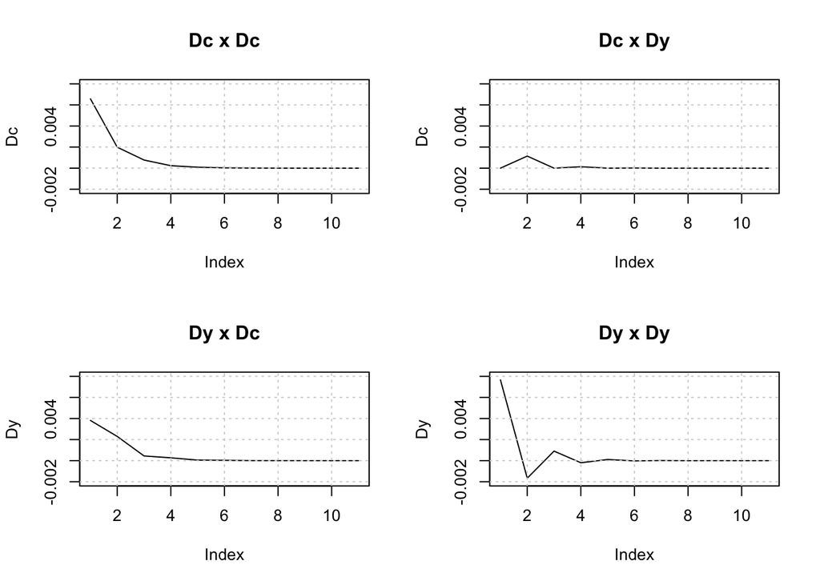

```r
impresp <- irf(varfit, boot = TRUE)
layout(matrix(1:4, nrow = 2))
# para colocar todos os gráficos na mesma escala
# vamos ajustar os limites superior e inferior das ordenadas
#
# cálculo do limite superior
impresp$irf %>% unlist %>% max -> mx
(mx %>% log10() %>% abs %>% ceiling) -> decs
mx = mx + 10^(-decs)*0.5
mx = round(mx, decs)
# cálculo do limite inferior
impresp$irf %>% unlist %>% min -> mi
if(mi>=0) {
  mi = 0
} else {
  (-mi %>% log10() %>% abs %>% ceiling) -> decs
  mi = mi - 10^(-decs)*0.5
  mi = round(mi, decs)
}
# limites do gráfico
ylim = c(mi, mx)
plot(impresp$irf$Dc[,1], type = "l", main = "Dc x Dc", ylab = "Dc", ylim = ylim);grid()
plot(impresp$irf$Dc[,2], type = "l", main = "Dy x Dc", ylab = "Dy", ylim = ylim);grid()
plot(impresp$irf$Dy[,1], type = "l", main = "Dc x Dy", ylab = "Dc", ylim = ylim);grid()
plot(impresp$irf$Dy[,2], type = "l", main = "Dy x Dy", ylab = "Dy", ylim = ylim);grid()
```

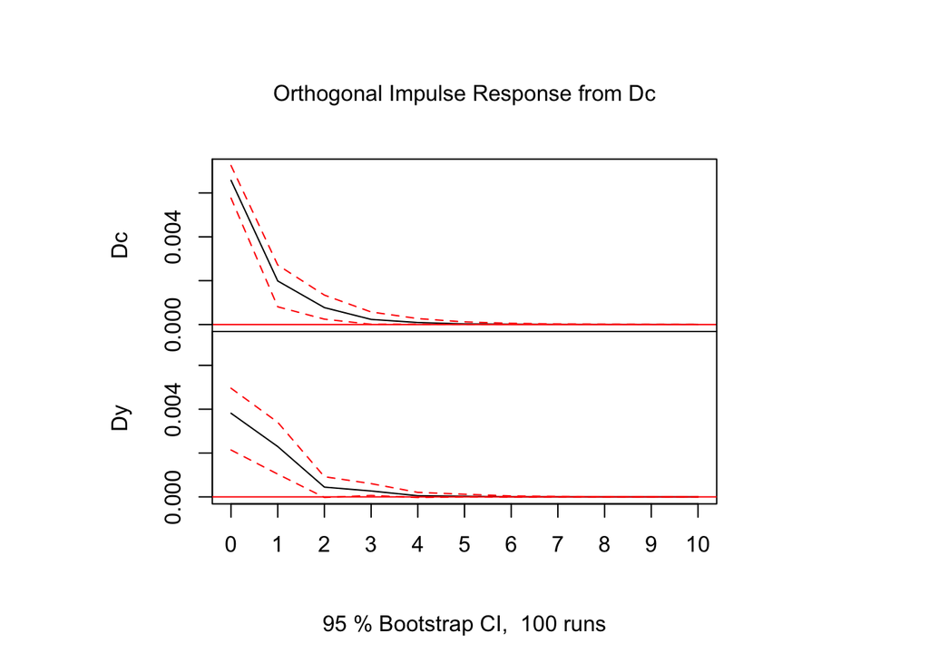

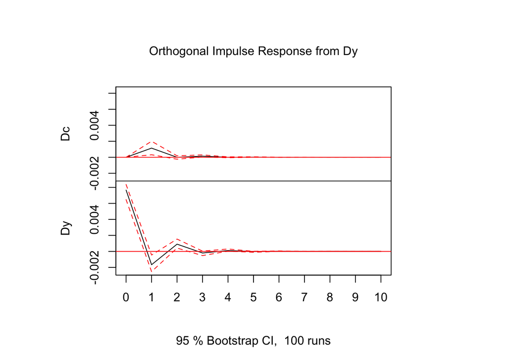

```r
#layout(matrix(1:4, ncol=2))
plot(impresp)
```

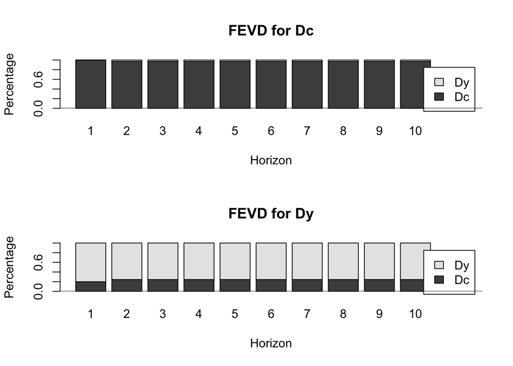

```r
plot(vars::fevd(varfit))
```